# Overview

Dataset info

| Number of variables | 16 |
| --- | --- |
| Number of observations | 45726 |
| Total Missing (%) | 15.1% |
| Total size in memory | 5.6 MiB |
| Average record size in memory | 128.0 B |

Variables types

| Numeric | 6 |
| --- | --- |
| Categorical | 7 |
| Boolean | 0 |
| Date | 0 |
| Text (Unique) | 1 |
| Rejected | 1 |
| Unsupported | 1 |

Warnings

- `Counties` has 44067 / 96.4% missing values Missing
- `GeoLocation` has 7315 / 16.0% missing values Missing
- `GeoLocation` has a high cardinality: 17101 distinct values Warning
- `States` has 44067 / 96.4% missing values Missing
- `mass (g)` is highly skewed (γ1 = 76.918) Skewed
- `recclass` has a high cardinality: 466 distinct values Warning
- `reclat` has 6438 / 14.1% zeros Zeros
- `reclat` has 7315 / 16.0% missing values Missing
- `reclat_city` is highly correlated with `reclat` (ρ = 0.99426) Rejected
- `reclong` has 6214 / 13.6% zeros Zeros
- `reclong` has 7315 / 16.0% missing values Missing
- `year` is an unsupported type, check if it needs cleaning or further analysis Warning

# Variables

Counties  
Numeric

| Distinct count | 663 |
| --- | --- |
| Unique (%) | 1.4% |
| Missing (%) | 96.4% |
| Missing (n) | 44067 |
| Infinite (%) | 0.0% |
| Infinite (n) | 0 |

| Mean | 1353.3 |
| --- | --- |
| Minimum | 5 |
| Maximum | 3210 |
| Zeros (%) | 0.0% |

Toggle details

**Statistics**

Quantile statistics

| Minimum | 5 |
| --- | --- |
| 5-th percentile | 30 |
| Q1 | 482 |
| Median | 1195 |
| Q3 | 2113 |
| 95-th percentile | 3109.1 |
| Maximum | 3210 |
| Range | 3205 |
| Interquartile range | 1631 |

Descriptive statistics

| Standard deviation | 994.09 |
| --- | --- |
| Coef of variation | 0.73455 |
| Kurtosis | -1.19 |
| Mean | 1353.3 |
| MAD | 874.35 |
| Skewness | 0.23764 |
| Sum | 2245200 |
| Variance | 988210 |
| Memory size | 357.3 KiB |

**Histogram**

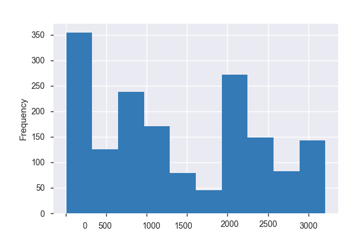

**Common Values**

| Value | Count | Frequency (%) |  |
| --- | --- | --- | --- |
| 78.0 | 187 | 0.4% |  |
| 1987.0 | 132 | 0.3% |  |
| 8.0 | 58 | 0.1% |  |
| 482.0 | 24 | 0.1% |  |
| 2357.0 | 22 | 0.0% |  |
| 799.0 | 20 | 0.0% |  |
| 801.0 | 19 | 0.0% |  |
| 3192.0 | 17 | 0.0% |  |
| 942.0 | 16 | 0.0% |  |
| 480.0 | 16 | 0.0% |  |
| Other values (652) | 1148 | 2.5% |  |
| (Missing) | 44067 | 96.4% |  |

**Extreme Values**

Minimum 5 values

| Value | Count | Frequency (%) |  |
| --- | --- | --- | --- |
| 5.0 | 10 | 0.0% |  |
| 7.0 | 6 | 0.0% |  |
| 8.0 | 58 | 0.1% |  |
| 9.0 | 1 | 0.0% |  |
| 10.0 | 1 | 0.0% |  |

Maximum 5 values

| Value | Count | Frequency (%) |  |
| --- | --- | --- | --- |
| 3188.0 | 10 | 0.0% |  |
| 3190.0 | 1 | 0.0% |  |
| 3192.0 | 17 | 0.0% |  |
| 3200.0 | 1 | 0.0% |  |
| 3210.0 | 1 | 0.0% |  |

GeoLocation  
Categorical

| Distinct count | 17101 |
| --- | --- |
| Unique (%) | 37.4% |
| Missing (%) | 16.0% |
| Missing (n) | 7315 |

| (0.0, 0.0) | 6214 |
| --- | --- |
| (-71.5, 35.66667) | 4761 |
| (-84.0, 168.0) | 3040 |
| Other values (17097) | 24396 |
| (Missing) | 7315 |

Toggle details

| Value | Count | Frequency (%) |  |
| --- | --- | --- | --- |
| (0.0, 0.0) | 6214 | 13.6% |  |
| (-71.5, 35.66667) | 4761 | 10.4% |  |
| (-84.0, 168.0) | 3040 | 6.6% |  |
| (-72.0, 26.0) | 1505 | 3.3% |  |
| (-79.68333, 159.75) | 657 | 1.4% |  |
| (-76.71667, 159.66667) | 637 | 1.4% |  |
| (-76.18333, 157.16667) | 539 | 1.2% |  |
| (-79.68333, 155.75) | 473 | 1.0% |  |
| (-84.21667, 160.5) | 263 | 0.6% |  |
| (-86.36667, -70.0) | 226 | 0.5% |  |
| Other values (17090) | 20096 | 43.9% |  |
| (Missing) | 7315 | 16.0% |  |

States  
Numeric

| Distinct count | 46 |
| --- | --- |
| Unique (%) | 0.1% |
| Missing (%) | 96.4% |
| Missing (n) | 44067 |
| Infinite (%) | 0.0% |
| Infinite (n) | 0 |

| Mean | 17.338 |
| --- | --- |
| Minimum | 1 |
| Maximum | 51 |
| Zeros (%) | 0.0% |

Toggle details

**Statistics**

Quantile statistics

| Minimum | 1 |
| --- | --- |
| 5-th percentile | 7 |
| Q1 | 9 |
| Median | 15 |
| Q3 | 23 |
| 95-th percentile | 39 |
| Maximum | 51 |
| Range | 50 |
| Interquartile range | 14 |

Descriptive statistics

| Standard deviation | 10.411 |
| --- | --- |
| Coef of variation | 0.60048 |
| Kurtosis | 0.69477 |
| Mean | 17.338 |
| MAD | 8.3381 |
| Skewness | 1.116 |
| Sum | 28763 |
| Variance | 108.39 |
| Memory size | 357.3 KiB |

**Histogram**

[figure not shown]

**Common Values**

| Value | Count | Frequency (%) |  |
| --- | --- | --- | --- |
| 23.0 | 297 | 0.6% |  |
| 8.0 | 224 | 0.5% |  |
| 11.0 | 222 | 0.5% |  |
| 17.0 | 139 | 0.3% |  |
| 7.0 | 120 | 0.3% |  |
| 10.0 | 95 | 0.2% |  |
| 9.0 | 87 | 0.2% |  |
| 19.0 | 49 | 0.1% |  |
| 20.0 | 40 | 0.1% |  |
| 37.0 | 29 | 0.1% |  |
| Other values (35) | 357 | 0.8% |  |
| (Missing) | 44067 | 96.4% |  |

**Extreme Values**

Minimum 5 values

| Value | Count | Frequency (%) |  |
| --- | --- | --- | --- |
| 1.0 | 7 | 0.0% |  |
| 2.0 | 6 | 0.0% |  |
| 3.0 | 9 | 0.0% |  |
| 4.0 | 2 | 0.0% |  |
| 5.0 | 6 | 0.0% |  |

Maximum 5 values

| Value | Count | Frequency (%) |  |
| --- | --- | --- | --- |
| 47.0 | 11 | 0.0% |  |
| 48.0 | 8 | 0.0% |  |
| 49.0 | 5 | 0.0% |  |
| 50.0 | 9 | 0.0% |  |
| 51.0 | 4 | 0.0% |  |

boolean  
Categorical

| Distinct count | 3 |
| --- | --- |
| Unique (%) | 0.0% |
| Missing (%) | 0.0% |
| Missing (n) | 10 |

| True | 23004 |
| --- | --- |
| False | 22712 |
| (Missing) | 10 |

Toggle details

| Value | Count | Frequency (%) |  |
| --- | --- | --- | --- |
| True | 23004 | 50.3% |  |
| False | 22712 | 49.7% |  |
| (Missing) | 10 | 0.0% |  |

fall  
Categorical

| Distinct count | 2 |
| --- | --- |
| Unique (%) | 0.0% |
| Missing (%) | 0.0% |
| Missing (n) | 0 |

| Found | 44609 |
| --- | --- |
| Fell | 1117 |

Toggle details

| Value | Count | Frequency (%) |  |
| --- | --- | --- | --- |
| Found | 44609 | 97.6% |  |
| Fell | 1117 | 2.4% |  |

id  
Numeric

| Distinct count | 45716 |
| --- | --- |
| Unique (%) | 100.0% |
| Missing (%) | 0.0% |
| Missing (n) | 0 |
| Infinite (%) | 0.0% |
| Infinite (n) | 0 |

| Mean | 26884 |
| --- | --- |
| Minimum | 1 |
| Maximum | 57458 |
| Zeros (%) | 0.0% |

Toggle details

**Statistics**

Quantile statistics

| Minimum | 1 |
| --- | --- |
| 5-th percentile | 2388.8 |
| Q1 | 12681 |
| Median | 24256 |
| Q3 | 40654 |
| 95-th percentile | 54891 |
| Maximum | 57458 |
| Range | 57457 |
| Interquartile range | 27972 |

Descriptive statistics

| Standard deviation | 16863 |
| --- | --- |
| Coef of variation | 0.62727 |
| Kurtosis | -1.1601 |
| Mean | 26884 |
| MAD | 14490 |
| Skewness | 0.26653 |
| Sum | 1229293495 |
| Variance | 284380000 |
| Memory size | 357.3 KiB |

**Histogram**

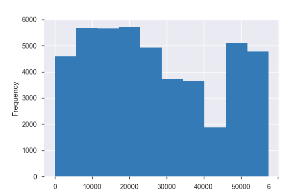

**Common Values**

| Value | Count | Frequency (%) |  |
| --- | --- | --- | --- |
| 417 | 2 | 0.0% |  |
| 398 | 2 | 0.0% |  |
| 1 | 2 | 0.0% |  |
| 6 | 2 | 0.0% |  |
| 392 | 2 | 0.0% |  |
| 370 | 2 | 0.0% |  |
| 379 | 2 | 0.0% |  |
| 2 | 2 | 0.0% |  |
| 390 | 2 | 0.0% |  |
| 10 | 2 | 0.0% |  |
| Other values (45706) | 45706 | 100.0% |  |

**Extreme Values**

Minimum 5 values

| Value | Count | Frequency (%) |  |
| --- | --- | --- | --- |
| 1 | 2 | 0.0% |  |
| 2 | 2 | 0.0% |  |
| 4 | 1 | 0.0% |  |
| 5 | 1 | 0.0% |  |
| 6 | 2 | 0.0% |  |

Maximum 5 values

| Value | Count | Frequency (%) |  |
| --- | --- | --- | --- |
| 57454 | 1 | 0.0% |  |
| 57455 | 1 | 0.0% |  |
| 57456 | 1 | 0.0% |  |
| 57457 | 1 | 0.0% |  |
| 57458 | 1 | 0.0% |  |

mass (g)  
Numeric

| Distinct count | 12577 |
| --- | --- |
| Unique (%) | 27.5% |
| Missing (%) | 0.3% |
| Missing (n) | 131 |
| Infinite (%) | 0.0% |
| Infinite (n) | 0 |

| Mean | 13278 |
| --- | --- |
| Minimum | 0 |
| Maximum | 60000000 |
| Zeros (%) | 0.0% |

Toggle details

**Statistics**

Quantile statistics

| Minimum | 0 |
| --- | --- |
| 5-th percentile | 1.1 |
| Q1 | 7.2 |
| Median | 32.61 |
| Q3 | 202.9 |
| 95-th percentile | 4000 |
| Maximum | 60000000 |
| Range | 60000000 |
| Interquartile range | 195.7 |

Descriptive statistics

| Standard deviation | 574930 |
| --- | --- |
| Coef of variation | 43.298 |
| Kurtosis | 6798.4 |
| Mean | 13278 |
| MAD | 25113 |
| Skewness | 76.918 |
| Sum | 605430000 |
| Variance | 330540000000 |
| Memory size | 357.3 KiB |

**Histogram**

[figure not shown]

**Common Values**

| Value | Count | Frequency (%) |  |
| --- | --- | --- | --- |
| 1.3 | 171 | 0.4% |  |
| 1.2 | 140 | 0.3% |  |
| 1.4 | 138 | 0.3% |  |
| 2.1 | 130 | 0.3% |  |
| 2.4 | 126 | 0.3% |  |
| 1.6 | 120 | 0.3% |  |
| 0.5 | 119 | 0.3% |  |
| 1.1 | 116 | 0.3% |  |
| 3.8 | 114 | 0.2% |  |
| 0.7 | 111 | 0.2% |  |
| Other values (12566) | 44310 | 96.9% |  |
| (Missing) | 131 | 0.3% |  |

**Extreme Values**

Minimum 5 values

| Value | Count | Frequency (%) |  |
| --- | --- | --- | --- |
| 0.0 | 19 | 0.0% |  |
| 0.01 | 2 | 0.0% |  |
| 0.013000000000000001 | 1 | 0.0% |  |
| 0.02 | 1 | 0.0% |  |
| 0.03 | 1 | 0.0% |  |

Maximum 5 values

| Value | Count | Frequency (%) |  |
| --- | --- | --- | --- |
| 28000000.0 | 1 | 0.0% |  |
| 30000000.0 | 1 | 0.0% |  |
| 50000000.0 | 1 | 0.0% |  |
| 58200000.0 | 1 | 0.0% |  |
| 60000000.0 | 1 | 0.0% |  |

mixed  
Categorical

| Distinct count | 3 |
| --- | --- |
| Unique (%) | 0.0% |
| Missing (%) | 0.0% |
| Missing (n) | 10 |

| 1 | 22975 |
| --- | --- |
| A | 22741 |
| (Missing) | 10 |

Toggle details

| Value | Count | Frequency (%) |  |
| --- | --- | --- | --- |
| 1 | 22975 | 50.2% |  |
| A | 22741 | 49.7% |  |
| (Missing) | 10 | 0.0% |  |

name  
Categorical, Unique

[output not shown]

[output not shown]

Toggle details

| Value | Count | Frequency (%) |  |
| --- | --- | --- | --- |
| Aachen | 1 | 0.0% |  |
| Aachen copy | 1 | 0.0% |  |
| Aarhus | 1 | 0.0% |  |
| Aarhus copy | 1 | 0.0% |  |
| Abajo | 1 | 0.0% |  |

| Value | Count | Frequency (%) |  |
| --- | --- | --- | --- |
| Österplana 062 | 1 | 0.0% |  |
| Österplana 063 | 1 | 0.0% |  |
| Österplana 064 | 1 | 0.0% |  |
| Łowicz | 1 | 0.0% |  |
| Święcany | 1 | 0.0% |  |

nametype  
Categorical

| Distinct count | 2 |
| --- | --- |
| Unique (%) | 0.0% |
| Missing (%) | 0.0% |
| Missing (n) | 0 |

| Valid | 45651 |
| --- | --- |
| Relict | 75 |

Toggle details

| Value | Count | Frequency (%) |  |
| --- | --- | --- | --- |
| Valid | 45651 | 99.8% |  |
| Relict | 75 | 0.2% |  |

recclass  
Categorical

| Distinct count | 466 |
| --- | --- |
| Unique (%) | 1.0% |
| Missing (%) | 0.0% |
| Missing (n) | 0 |

| L6 | 8287 |
| --- | --- |
| H5 | 7143 |
| L5 | 4797 |
| Other values (463) | 25499 |

Toggle details

| Value | Count | Frequency (%) |  |
| --- | --- | --- | --- |
| L6 | 8287 | 18.1% |  |
| H5 | 7143 | 15.6% |  |
| L5 | 4797 | 10.5% |  |
| H6 | 4529 | 9.9% |  |
| H4 | 4211 | 9.2% |  |
| LL5 | 2766 | 6.0% |  |
| LL6 | 2043 | 4.5% |  |
| L4 | 1253 | 2.7% |  |
| H4/5 | 428 | 0.9% |  |
| CM2 | 416 | 0.9% |  |
| Other values (456) | 9853 | 21.5% |  |

reclat  
Numeric

| Distinct count | 12739 |
| --- | --- |
| Unique (%) | 27.9% |
| Missing (%) | 16.0% |
| Missing (n) | 7315 |
| Infinite (%) | 0.0% |
| Infinite (n) | 0 |

| Mean | -39.107 |
| --- | --- |
| Minimum | -87.367 |
| Maximum | 81.167 |
| Zeros (%) | 14.1% |

Toggle details

**Statistics**

Quantile statistics

| Minimum | -87.367 |
| --- | --- |
| 5-th percentile | -84.355 |
| Q1 | -76.714 |
| Median | -71.5 |
| Q3 | 0 |
| 95-th percentile | 34.494 |
| Maximum | 81.167 |
| Range | 168.53 |
| Interquartile range | 76.714 |

Descriptive statistics

| Standard deviation | 46.386 |
| --- | --- |
| Coef of variation | -1.1861 |
| Kurtosis | -1.4769 |
| Mean | -39.107 |
| MAD | 43.937 |
| Skewness | 0.49132 |
| Sum | -1502100 |
| Variance | 2151.7 |
| Memory size | 357.3 KiB |

**Histogram**

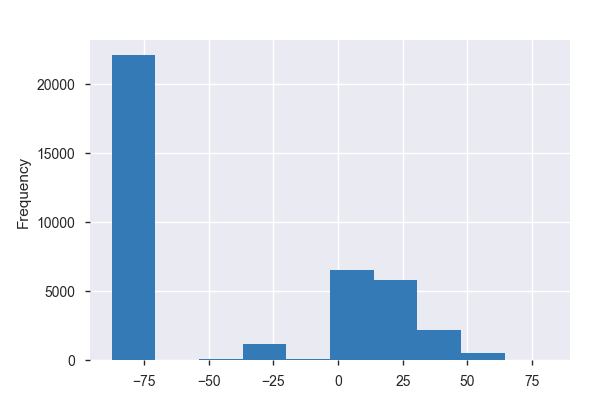

**Common Values**

| Value | Count | Frequency (%) |  |
| --- | --- | --- | --- |
| 0.0 | 6438 | 14.1% |  |
| -71.5 | 4761 | 10.4% |  |
| -84.0 | 3040 | 6.6% |  |
| -72.0 | 1506 | 3.3% |  |
| -79.68333 | 1130 | 2.5% |  |
| -76.71667 | 680 | 1.5% |  |
| -76.18333 | 539 | 1.2% |  |
| -84.21667 | 263 | 0.6% |  |
| -86.36667 | 226 | 0.5% |  |
| -86.71667 | 217 | 0.5% |  |
| Other values (12728) | 19611 | 42.9% |  |
| (Missing) | 7315 | 16.0% |  |

**Extreme Values**

Minimum 5 values

| Value | Count | Frequency (%) |  |
| --- | --- | --- | --- |
| -87.36667 | 4 | 0.0% |  |
| -87.03333 | 3 | 0.0% |  |
| -86.93333 | 3 | 0.0% |  |
| -86.71667 | 217 | 0.5% |  |
| -86.56667 | 17 | 0.0% |  |

Maximum 5 values

| Value | Count | Frequency (%) |  |
| --- | --- | --- | --- |
| 72.68333 | 1 | 0.0% |  |
| 72.88333 | 1 | 0.0% |  |
| 76.13333 | 1 | 0.0% |  |
| 76.53333 | 1 | 0.0% |  |
| 81.16667 | 1 | 0.0% |  |

reclat_city  
Highly correlated

*This variable is highly correlated with `reclat` and should be ignored for analysis*

| Correlation | 0.99426 |
| --- | --- |

reclong  
Numeric

| Distinct count | 14641 |
| --- | --- |
| Unique (%) | 32.0% |
| Missing (%) | 16.0% |
| Missing (n) | 7315 |
| Infinite (%) | 0.0% |
| Infinite (n) | 0 |

| Mean | 61.053 |
| --- | --- |
| Minimum | -165.43 |
| Maximum | 354.47 |
| Zeros (%) | 13.6% |

Toggle details

**Statistics**

Quantile statistics

| Minimum | -165.43 |
| --- | --- |
| 5-th percentile | -90.427 |
| Q1 | 0 |
| Median | 35.667 |
| Q3 | 157.17 |
| 95-th percentile | 168 |
| Maximum | 354.47 |
| Range | 519.91 |
| Interquartile range | 157.17 |

Descriptive statistics

| Standard deviation | 80.655 |
| --- | --- |
| Coef of variation | 1.3211 |
| Kurtosis | -0.73139 |
| Mean | 61.053 |
| MAD | 67.606 |
| Skewness | -0.17438 |
| Sum | 2345100 |
| Variance | 6505.3 |
| Memory size | 357.3 KiB |

**Histogram**

[figure not shown]

**Common Values**

| Value | Count | Frequency (%) |  |
| --- | --- | --- | --- |
| 0.0 | 6214 | 13.6% |  |
| 35.66667 | 4985 | 10.9% |  |
| 168.0 | 3040 | 6.6% |  |
| 26.0 | 1506 | 3.3% |  |
| 159.75 | 657 | 1.4% |  |
| 159.66666999999998 | 637 | 1.4% |  |
| 157.16666999999998 | 542 | 1.2% |  |
| 155.75 | 473 | 1.0% |  |
| 160.5 | 263 | 0.6% |  |
| -70.0 | 228 | 0.5% |  |
| Other values (14630) | 19866 | 43.4% |  |
| (Missing) | 7315 | 16.0% |  |

**Extreme Values**

Minimum 5 values

| Value | Count | Frequency (%) |  |
| --- | --- | --- | --- |
| -165.43333 | 9 | 0.0% |  |
| -165.11667 | 17 | 0.0% |  |
| -163.16666999999998 | 1 | 0.0% |  |
| -162.55 | 1 | 0.0% |  |
| -157.86667 | 1 | 0.0% |  |

Maximum 5 values

| Value | Count | Frequency (%) |  |
| --- | --- | --- | --- |
| 175.13333 | 1 | 0.0% |  |
| 175.73028 | 1 | 0.0% |  |
| 178.08333000000002 | 1 | 0.0% |  |
| 178.2 | 1 | 0.0% |  |
| 354.47333 | 1 | 0.0% |  |

source  
Categorical

| Distinct count | 2 |
| --- | --- |
| Unique (%) | 0.0% |
| Missing (%) | 0.0% |
| Missing (n) | 10 |

| NASA | 45716 |
| --- | --- |
| (Missing) | 10 |

Toggle details

| Value | Count | Frequency (%) |  |
| --- | --- | --- | --- |
| NASA | 45716 | 100.0% |  |
| (Missing) | 10 | 0.0% |  |

year  
Unsupported

*This variable is an unsupported type, check if it needs cleaning or further analysis*

| Unsupported value |
| --- |

# Sample

|  | Counties | GeoLocation | States | boolean | fall | id | mass (g) | mixed | name | nametype | recclass | reclat | reclat_city | reclong | source | year |
| --- | --- | --- | --- | --- | --- | --- | --- | --- | --- | --- | --- | --- | --- | --- | --- | --- |
| 0 | NaN | (50.775, 6.08333) | NaN | False | Fell | 1 | 21.0 | 1 | Aachen | Valid | L5 | 50.77500 | 59.729586 | 6.08333 | NASA | 1880-01-01 00:00:00 |
| 1 | NaN | (56.18333, 10.23333) | NaN | True | Fell | 2 | 720.0 | 1 | Aarhus | Valid | H6 | 56.18333 | 64.139917 | 10.23333 | NASA | 1951-01-01 00:00:00 |
| 2 | NaN | (54.21667, -113.0) | NaN | True | Fell | 6 | 107000.0 | A | Abee | Valid | EH4 | 54.21667 | 53.756896 | -113.00000 | NASA | 1952-01-01 00:00:00 |
| 3 | NaN | (16.88333, -99.9) | NaN | True | Fell | 10 | 1914.0 | 1 | Acapulco | Valid | Acapulcoite | 16.88333 | 5.041571 | -99.90000 | NASA | 1976-01-01 00:00:00 |
| 4 | NaN | (-33.16667, -64.95) | NaN | True | Fell | 370 | 780.0 | 1 | Achiras | Valid | L6 | -33.16667 | -27.266614 | -64.95000 | NASA | 1902-01-01 00:00:00 |